# Harmonized Drug Dataset v3.2 Quality Control

James Bannon, Michael Tran

November 27, 2026

# 1 Overview

This report is a quality control walkthrough for the lab-generated Harmonized Drug Dataset stored as a `MultiAssayExperiment` (MAE). The dataset harmonizes multiple drug-related assays and features across a shared compound universe keyed by `HDD.Compound.ID` so downstream analyses can operate on a consistent sample space. `Pubchem.CID` is retained when available, but it is not required for a compound to be included.

## 1.1 Data Sources

This report describes the HDD object and its compound annotations, assays and features. Key sources include:

- **Tox21**: NCATS 2014 Challenge training archive, matched by unique full InChIKey. Discordant calls are set to missing for that compound and assay.
- **DeepChem BBBP**: retained as blood–brain barrier permeability metadata in `colData`, not as a separate assay.
- **JUMP-CP** membership and source identifiers from the curated cpg0016 MAE.
- **OASIS** membership and source identifiers from the curated cpg0037 MAE.
- **GEOM** membership and source identifiers from the curated GEOM MAE.
- **LINCS** membership and source identifiers from the curated LINCS MAE.
- **CTRPv2** membership and master compound identifiers from the CTRPv2 PharmacoSet.
- **NCI60** membership and NSC identifiers from the NCI60-2026 PharmacoSet.
- **Bioassays**: pulled from AnnotationDB alongside compound metadata, with bioassays filtered to gold-standard assays.
- **Drug indications**: ChEMBL indication records pulled from AnnotationDB and stored as a long table in MAE metadata rather than flattened into `colData`.
- **ATC codes**: pulled from AnnotationDB when an authorization key is available.
- **LTKB**: DILI labels pulled from AnnotationDB for the LTKB Benchmark Dataset, DILIrank, and DILIst label sets.
- **LiverTox**: hepatotoxicity likelihood score and reason pulled from AnnotationDB.
- **DIRIL and DICT**: renal and cardiac toxicity labels pulled from AnnotationDB.
- **DailyMed**: selected product labels supplied by AnnotationDB, including boxed warnings, warnings/precautions and adverse reactions.
- **Fingerprints**: RDKit Morgan count fingerprints generated for compounds with parseable SMILES.

# 2 Load HDD

```
## A MultiAssayExperiment object of 6 listed
##  experiments with user-defined names and respective classes.
##  Containing an ExperimentList class object of length 6:
##  [1] Bioassays: SummarizedExperiment with 33 rows and 438498 columns
##  [2] Tox21: SummarizedExperiment with 12 rows and 6134 columns
##  [3] fingerprint.Morgan.2.1024: SummarizedExperiment with 1024 rows and 646039 columns
##  [4] fingerprint.Morgan.2.2048: SummarizedExperiment with 2048 rows and 646039 columns
##  [5] fingerprint.Morgan.3.1024: SummarizedExperiment with 1024 rows and 646039 columns
##  [6] fingerprint.Morgan.3.2048: SummarizedExperiment with 2048 rows and 646039 columns
## Functionality:
##  experiments() - obtain the ExperimentList instance
##  colData() - the primary/phenotype DataFrame
##  sampleMap() - the sample coordination DataFrame
##  `$`, `[`, `[[` - extract colData columns, subset, or experiment
##  *Format() - convert into a long or wide DataFrame
##  assays() - convert ExperimentList to a SimpleList of matrices
##  exportClass() - save data to flat files
```

## 2.1 Dataset version

Dataset **HDD_v3.2**, version **3.2.0**.

The walkthrough reads the saved HDD object. See the [results inventory](https://github.com/bhklab/hdd-data-pipeline/tree/main/data/results) for the companion exports. ADAPT agents-of-interest coverage was not assessed in this report.

## 2.2 Basic access examples

The examples below show the intended access pattern for release metadata, compound annotations, one assay matrix, and a small analysis-ready table. They operate on the object already loaded by this report and do not query a live service.

```r
# Release and long-form metadata
S4Vectors::metadata(hdd_mae)$Pipeline[c("ID", "Version")]
```

```
## $ID
## [1] "HDD_v3.2"
##
## $Version
## [1] "3.2.0"
```

```r
head(S4Vectors::metadata(hdd_mae)$Drug.Indications, 5)
```

```
## DataFrame with 5 rows and 19 columns
##    HDD.Compound.ID Pubchem.CID ChEMBL.Drug.Indication.ID Molecule.ChEMBL.ID
##        <character>   <integer>                 <integer>        <character>
## 1 HDD_11CAbAxvILTY     5362065                     41830         CHEMBL1541
## 2 HDD_11CAbAxvILTY     5362065                     62371         CHEMBL1541
## 3 HDD_11CAbAxvILTY     5362065                     62372         CHEMBL1541
## 4 HDD_11CAbAxvILTY     5362065                     62373         CHEMBL1541
## 5 HDD_11CAbAxvILTY     5362065                     62374         CHEMBL1541
##   Parent.Molecule.ChEMBL.ID Child.Molecule.ChEMBL.ID Maximum.Indication.Phase
##                 <character>              <character>                <numeric>
## 1                CHEMBL1541                       NA                      4.0
## 2                CHEMBL1541                       NA                      4.0
## 3                CHEMBL1541                       NA                      1.0
## 4                CHEMBL1541                       NA                      0.5
## 5                CHEMBL1541                       NA                      4.0
##       MeSH.ID           MeSH.Heading      EFO.ID               EFO.Term
##   <character>            <character> <character>            <character>
## 1     D010033           Otitis Media EFO:0004992           Otitis media
## 2     D007239             Infections EFO:0000544              infection
## 3     D009369              Neoplasms EFO:0000616               neoplasm
## 4     D010019          Osteomyelitis EFO:0003102          osteomyelitis
## 5     D014552 Urinary Tract Infect.. EFO:0003103 urinary tract infect..
##   Clinical.Trial.Reference.IDs DailyMed.Reference.IDs EMA.Reference.IDs
##                    <character>            <character>       <character>
## 1                           NA 5007152e-a679-4e85-a..                NA
## 2       NCT03329547,NCT03840.. 69234c9d-fc0f-49b1-8..                NA
## 3       NCT00004216,NCT00186..                     NA                NA
## 4                  NCT02099240                     NA                NA
## 5                  NCT01595529 ef6f6181-baa6-4896-a..                NA
##   FDA.Reference.IDs USAN.Reference.IDs INN.Reference.IDs Inferred.From.Parent
##         <character>        <character>       <character>            <logical>
## 1                NA                 NA                NA                FALSE
## 2                NA                 NA                NA                FALSE
## 3                NA                 NA                NA                FALSE
## 4                NA                 NA                NA                FALSE
## 5                NA                 NA                NA                FALSE
##   Inferred.From.Child
##             <logical>
## 1               FALSE
## 2               FALSE
## 3               FALSE
## 4               FALSE
## 5               FALSE
```

```r
# Compound metadata
compound_metadata_example <- as.data.frame(colData(hdd_mae)) |>
  select(
    HDD.Compound.ID,
    Molecule.Name,
    Pubchem.CID,
    ChEMBL.ID,
    In.AnnotationDB
  ) |>
  slice_head(n = 10)
compound_metadata_example
```

|  | HDD.Compound.ID | Molecule.Name | Pubchem.CID | ChEMBL.ID | In.AnnotationDB |
| --- | --- | --- | --- | --- | --- |
| HDD_100Qq7ZWzc84 | HDD_100Qq7ZWzc84 | (+/-)-(7-Cyano-4-pyridin-2-ylmethyl-1,2,3,4-tetrahydro-cyclopenta[b]indol-2-yl)-carbamic acid isopropyl ester | 59242746 | NA | TRUE |
| HDD_100VcBf7xNmF | HDD_100VcBf7xNmF | 743693 | 45028681 | NA | FALSE |
| HDD_100qxkzFVw1Y | HDD_100qxkzFVw1Y | 2-Propylfuran | 77907 | NA | TRUE |
| HDD_101gEGLkpWU6 | HDD_101gEGLkpWU6 | 832929 | 172408060 | NA | FALSE |
| HDD_101w9WD4OfLl | HDD_101w9WD4OfLl | 745180 | 45029002 | NA | FALSE |
| HDD_101xneHl8ces | HDD_101xneHl8ces | 1-[3-[2-(3-Methylpyrazin-2-yl)ethyl]morpholin-4-yl]-2-(2-methyl-1,3-thiazol-4-yl)ethanone | 110132319 | NA | TRUE |
| HDD_102MEPXgQBRc | HDD_102MEPXgQBRc | N-[5-(2,3-dihydro-1,4-benzodioxin-6-yl)-1,3,4-oxadiazol-2-yl]-3-phenoxypropanamide | 3304918 | CHEMBL1392602 | TRUE |
| HDD_105EXyYgqwjS | HDD_105EXyYgqwjS | 1-(2-Methyl-2,3-dihydroindol-1-yl)-2-[2-morpholin-4-yl-5-(trifluoromethyl)anilino]ethanone | 4878858 | NA | TRUE |
| HDD_105YnfuNS7oD | HDD_105YnfuNS7oD | 3-(4-oxo-3H-phthalazin-1-yl)-N-(2-piperidin-1-ylethyl)benzamide | 121495997 | NA | TRUE |
| HDD_105polbQ4abG | HDD_105polbQ4abG | 4-(3,4-dimethylpyridinium-1-yl)-2-oxo-5-{(E)-[2-(pyridin-4-ylcarbonyl)hydrazinylidene]methyl}-1,3-thiazol-3-ide | 135650371 | NA | TRUE |

```r
# One assay and a compact joined summary
tox21_matrix <- assay(experiments(hdd_mae)[["Tox21"]])
tox21_matrix[1:min(5, nrow(tox21_matrix)), 1:min(6, ncol(tox21_matrix))]
```

|  | HDD_10OljUbbqjzM | HDD_11BV4iHE6N8k | HDD_11EYa1tYTOyP | HDD_11T787bbL3ns | HDD_121lXAdujLmE | HDD_127IkCzLXInA |
| --- | --- | --- | --- | --- | --- | --- |
| NR-AR | 0 | 0 | 0 | NA | 0 | 0 |
| NR-AR-LBD | NA | 0 | 0 | NA | 0 | 0 |
| NR-AhR | 0 | 0 | 0 | NA | 0 | 0 |
| NR-Aromatase | NA | 0 | 0 | NA | 0 | 0 |
| NR-ER | NA | 0 | 0 | NA | NA | 0 |

```r
tox21_analysis_ready <- tibble::tibble(
  HDD.Compound.ID = colnames(tox21_matrix),
  measured_assays = colSums(!is.na(tox21_matrix)),
  positive_assays = colSums(tox21_matrix == 1, na.rm = TRUE)
) |>
  left_join(
    as.data.frame(colData(hdd_mae)) |>
      select(HDD.Compound.ID, Molecule.Name, Pubchem.CID),
    by = "HDD.Compound.ID"
  ) |>
  arrange(desc(positive_assays), HDD.Compound.ID) |>
  slice_head(n = 20)
tox21_analysis_ready
```

| HDD.Compound.ID | measured_assays | positive_assays | Molecule.Name | Pubchem.CID |
| --- | --- | --- | --- | --- |
| HDD_vBf7ZdtoAiAq | 9 | 9 | 2,2':5',2''-Terthiophene | 65067 |
| HDD_EBVzYbHl9End | 10 | 8 | 4-Nitrosodiphenylamine | 9074 |
| HDD_GNt3eYIvZcxf | 10 | 8 | Crystal Violet | 11057 |
| HDD_1iDAHfvqFrGi | 10 | 7 | Apigenin | 5280443 |
| HDD_7KkV6Q4IKynF | 8 | 7 | Lacidipine | 5311217 |
| HDD_BEuuto0h7zwC | 11 | 7 | 1-Amino-2-methylanthraquinone | 6702 |
| HDD_DuibsPTGiPSH | 8 | 7 | Pyrithione Zinc | 26041 |
| HDD_Et3EmgFqTECV | 9 | 7 | Dinaline | 42725 |
| HDD_awQG61OGZHfL | 9 | 7 | Triethyltin bromide | 17701 |
| HDD_bNQzX4fnB0HA | 10 | 7 | Genistein | 5280961 |

[output cut: 10 more lines]

# 3 MAE snapshot

```
## [1] "Bioassays"                 "Tox21"
## [3] "fingerprint.Morgan.2.1024" "fingerprint.Morgan.2.2048"
## [5] "fingerprint.Morgan.3.1024" "fingerprint.Morgan.3.2048"
```

|  | assay_name | rows | cols | row_metadata_fields | data_class | missing_fraction |
| --- | --- | --- | --- | --- | --- | --- |
| Bioassays | Bioassays | 33 | 438498 | 0 | data.frame | 0.960 |
| Tox21 | Tox21 | 12 | 6134 | 0 | data.frame | 0.179 |
| fingerprint.Morgan.2.1024 | fp.name | 1024 | 646039 | 0 | dgCMatrix | 0.000 |
| fingerprint.Morgan.2.2048 | fp.name | 2048 | 646039 | 0 | dgCMatrix | 0.000 |
| fingerprint.Morgan.3.1024 | fp.name | 1024 | 646039 | 0 | dgCMatrix | 0.000 |
| fingerprint.Morgan.3.2048 | fp.name | 2048 | 646039 | 0 | dgCMatrix | 0.000 |

| source | flag_column | compound_count |
| --- | --- | --- |
| LINCS | In.LINCS | 20785 |
| JUMP-CP | In.JUMP.CP | 115730 |
| OASIS | In.OASIS | 1086 |
| GEOM | In.GEOM | 301536 |
| CTRPv2 | In.CTRP | 545 |
| NCI60 | In.NCI60 | 134716 |

| source | flag_column | key_column | member_compounds | members_with_source_key | key_coverage |
| --- | --- | --- | --- | --- | --- |
| LINCS | In.LINCS | LINCS.CMap.Name | 20785 | 20785 | 1.00 |
| JUMP-CP | In.JUMP.CP | JUMP.CP.ID | 115730 | 115730 | 1.00 |
| OASIS | In.OASIS | OASIS.ID | 1086 | 966 | 0.89 |
| GEOM | In.GEOM | GEOM.Source.SMILES | 301536 | 301536 | 1.00 |
| CTRPv2 | In.CTRP | CTRP.Master.CPD.ID | 545 | 545 | 1.00 |
| NCI60 | In.NCI60 | NCI60.NSC | 134716 | 134716 | 1.00 |

| status | compounds |
| --- | --- |
| In AnnotationDB | 438498 |
| Not in AnnotationDB | 209624 |

| colData_rows | sampleMap_primary_ids | colData_rows_absent_from_sampleMap |
| --- | --- | --- |
| 648122 | 646042 | 2080 |

# 4 colData overview

```
## DataFrame with 5 rows and 10 columns
##                   HDD.Compound.ID Pubchem.CID               InChIKey
##                       <character>   <integer>            <character>
## HDD_100Qq7ZWzc84 HDD_100Qq7ZWzc84    59242746 IHIWYQYVBNODSV-UHFFF..
## HDD_100VcBf7xNmF HDD_100VcBf7xNmF    45028681                     NA
## HDD_100qxkzFVw1Y HDD_100qxkzFVw1Y       77907 CPLJMYOQYRCCBY-UHFFF..
## HDD_101gEGLkpWU6 HDD_101gEGLkpWU6   172408060                     NA
## HDD_101w9WD4OfLl HDD_101w9WD4OfLl    45029002                     NA
##                                    SMILES          Molecule.Name
##                               <character>            <character>
## HDD_100Qq7ZWzc84   CC(C)OC(=O)NC1CC2=C(.. (+/-)-(7-Cyano-4-pyr..
## HDD_100VcBf7xNmF  COc1ccc2O\\C(=C/c3ccc..                 743693
## HDD_100qxkzFVw1Y             CCCC1=CC=CO1          2-Propylfuran
## HDD_101gEGLkpWU6 Cc1onc(c1)\\N=C\\2/NC(..                 832929
## HDD_101w9WD4OfLl   COc1ccc(cc1)C(=O)COc..                 745180
##                  In.AnnotationDB      AnnotationDB.Name    AnnotationDB.SMILES
##                        <logical>            <character>            <character>
## HDD_100Qq7ZWzc84            TRUE (+/-)-(7-Cyano-4-pyr.. CC(C)OC(=O)NC1CC2=C(..
## HDD_100VcBf7xNmF           FALSE                     NA                     NA
## HDD_100qxkzFVw1Y            TRUE          2-Propylfuran           CCCC1=CC=CO1
## HDD_101gEGLkpWU6           FALSE                     NA                     NA
## HDD_101w9WD4OfLl           FALSE                     NA                     NA
##                  In.JUMP.CP     JUMP.CP.ID
##                   <logical>    <character>
## HDD_100Qq7ZWzc84       TRUE JCP2022_035074
## HDD_100VcBf7xNmF      FALSE             NA
## HDD_100qxkzFVw1Y      FALSE             NA
## HDD_101gEGLkpWU6      FALSE             NA
## HDD_101w9WD4OfLl      FALSE             NA
```

```
##                           HDD.Compound.ID
##                                   0.00000
##                               Pubchem.CID
##                                   0.16263
##                                  InChIKey
##                                   0.06762
##                                    SMILES
##                                   0.00151
##                             Molecule.Name
##                                   0.00000
##                           In.AnnotationDB
##                                   0.00000
##                         AnnotationDB.Name
##                                   0.32343
##                       AnnotationDB.SMILES
##                                   0.32343
##                                In.JUMP.CP
##                                   0.00000
##                                JUMP.CP.ID
##                                   0.82144
##                                  In.OASIS
##                                   0.00000
##                                  OASIS.ID
##                                   0.99851
##                                   In.GEOM
##                                   0.00000
##                        GEOM.Source.SMILES
##                                   0.53475
##                                  In.LINCS
##                                   0.00000
##                           LINCS.CMap.Name
##                                   0.96793
##                                   In.CTRP
##                                   0.00000
##                        CTRP.Master.CPD.ID
##                                   0.99916
##                                  In.NCI60
##                                   0.00000
##                                 NCI60.NSC
##                                   0.79214
```

[output cut: 65 more lines]

```
##                                   0.99730
##                   DailyMed.Published.Date
##                                   0.99730
##             DailyMed.Is.Single.Ingredient
##                                   0.99730
##                    DailyMed.Boxed.Warning
##                                   0.99914
##         DailyMed.Warnings.and.Precautions
##                                   0.99733
##                DailyMed.Adverse.Reactions
##                                   0.99738
##                        DailyMed.Label.URL
##                                   0.99730
##                 DailyMed.Retrieved.At.UTC
##                                   0.99730
```

```
##             n_compounds          unique_hdd_ids unique_non_missing_cids
##                  648122                  648122                  542720
```

## 4.1 DailyMed labels

DailyMed adds boxed warnings, warnings/precautions and adverse reactions to compound metadata. Labels are matched by exact PubChem CID and retain the selected label identifier, version and publication date.

1,750 compounds with a returned label

| Field | Populated | Missing (null) | Empty text |
| --- | --- | --- | --- |
| Boxed warning | 559 | 1191 | 0 |
| Warnings / precautions | 1727 | 21 | 2 |
| Adverse reactions | 1695 | 55 | 0 |

Across HDD, 436,748 compounds were found in AnnotationDB without a label, 104,222 compounds with CIDs were not returned, and 105,402 compounds have no PubChem CID. These outcomes differ from a returned label with a missing or empty section. **Missing text does not establish that a warning is absent.**

The 1,750 compound annotations represent 1,432 distinct label-set/version pairs; 308 are shared across CIDs. AnnotationDB selected one label per compound, with multiple candidates reported for 1,167 compounds. These selections are not exhaustive and may be formulation-specific or historical. The plot counts each selected label-set/version once; the median publication date is 2026-04-04.

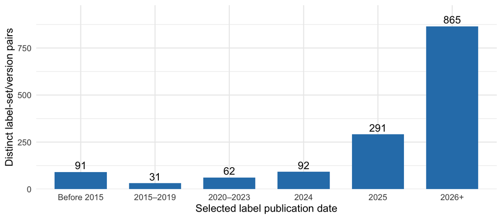

The examples below show annotated compounds and short label excerpts. Expand a row to view its text. Full sections remain in `colData`; excerpts are shortened only for display. Source text is retained verbatim; consult the source label for unreadable passages.

**Doxorubicin — CID 31703**

Published 2026-06-03; label version 13; 5 reported candidate(s). [DailyMed label set](https://dailymed.nlm.nih.gov/dailymed/drugInfo.cfm?setid=1c153e9e-4cf2-4ac7-9cf9-16f9b48d7dce)

**Boxed warning:** WARNING: CARDIOMYOPATHY and INFUSION-RELATED REACTIONS DOXIL liposomal infusion can cause myocardial damage, including acute left ventricular failure. The risk of cardiomyopathy was 11% when the cumulative anthracycline …

**Warnings / precautions:** 5.1 Cardiomyopathy: Doxorubicin hydrochloride can cause myocardial damage, including acute left ventricular failure. The risk of cardiomyopathy with doxorubicin hydrochloride is generally proportional to the cumulative e…

**Adverse reactions:** The following adverse reactions are discussed in more detail in other sections of the labeling. Cardiomyopathy Infusion-Related Reactions Hand-Foot Syndrome Secondary Oral Neoplasms 6.1 Clinical Trials Experience: Becaus…

**Erlotinib — CID 176870**

Published 2012-01-30; label version 1; 1 reported candidate(s). [DailyMed label set](https://dailymed.nlm.nih.gov/dailymed/drugInfo.cfm?setid=5783976b-0862-44e5-9b19-0f41d236d5c3)

**Boxed warning:** *Missing in source (null).*

**Warnings / precautions:** 5.1 Pulmonary Toxicity: There have been infrequent reports of serious Interstitial Lung Disease (ILD)-like events, including fatalities, in patients receiving TARCEVA for treatment of NSCLC, pancreatic cancer or other ad…

**Adverse reactions:** Because clinical trials are conducted under widely varying conditions, adverse reactions rates observed in the clinical trials of a drug cannot be directly compared to rates in the clinical trials of another drug and may…

**6-Mercaptopurine — CID 667490**

Published 2026-07-22; label version 30; 2 reported candidate(s). [DailyMed label set](https://dailymed.nlm.nih.gov/dailymed/drugInfo.cfm?setid=9fd27952-7787-47d9-b6cf-7af2dc38217b)

**Boxed warning:** *Missing in source (null).*

**Warnings / precautions:** *Empty source text (0 characters).*

**Adverse reactions:** The following clinically significant adverse reactions are described elsewhere in the labeling: Myelosuppression Hepatotoxicity [ Immunosuppression [ Treatment Related Malignancies [ Macrophage Activation Syndrome [

## 4.2 Long-form drug indications

Drug indication records are one-to-many with compounds and therefore remain a long table in `metadata(hdd_mae)$Drug.Indications`. This preserves repeated compound–indication associations in the data.

| indication_rows | compounds_with_indications | unique_chembl_indications | invalid_compound_foreign_keys |
| --- | --- | --- | --- |
| 55506 | 4845 | 40765 | 0 |

|  | HDD.Compound.ID | Pubchem.CID | ChEMBL.Drug.Indication.ID | Molecule.ChEMBL.ID | Parent.Molecule.ChEMBL.ID | Child.Molecule.ChEMBL.ID | Maximum.Indication.Phase | MeSH.ID | MeSH.Heading | EFO.ID | EFO.Term | Clinical.Trial.Reference.IDs | DailyMed.Reference.IDs | EMA.Reference.IDs | FDA.Reference.IDs | USAN.Reference.IDs | INN.Reference.IDs | Inferred.From.Parent | Inferred.From.Child |
| --- | --- | --- | --- | --- | --- | --- | --- | --- | --- | --- | --- | --- | --- | --- | --- | --- | --- | --- | --- |
| 1 | HDD_11CAbAxvILTY | 5362065 | 41830 | CHEMBL1541 | CHEMBL1541 | NA | 4.0 | D010033 | Otitis Media | EFO:0004992 | Otitis media | NA | 5007152e-a679-4e85-ac3f-c46087812774,567c8c7a-72ca-47cc-93a8-b59e55d2aa56,69234c9d-fc0f-49b1-8345-e0fe48ed0699,7e2462b2-bfed-4da4-8c47-46838d6153f8,cfba00cb-e332-43d4-a4fc-8898ceb7fbcc,d0fd45bd-7d52-4… | NA | NA | NA | NA | FALSE | FALSE |
| 2 | HDD_11CAbAxvILTY | 5362065 | 62371 | CHEMBL1541 | CHEMBL1541 | NA | 4.0 | D007239 | Infections | EFO:0000544 | infection | NCT03329547,NCT03840811 | 69234c9d-fc0f-49b1-8345-e0fe48ed0699,ef6f6181-baa6-4896-abfa-2097afe1f087 | NA | NA | NA | NA | FALSE | FALSE |
| 3 | HDD_11CAbAxvILTY | 5362065 | 62372 | CHEMBL1541 | CHEMBL1541 | NA | 1.0 | D009369 | Neoplasms | EFO:0000616 | neoplasm | NCT00004216,NCT00186979,NCT00786669,NCT02596503 | NA | NA | NA | NA | NA | FALSE | FALSE |
| 4 | HDD_11CAbAxvILTY | 5362065 | 62373 | CHEMBL1541 | CHEMBL1541 | NA | 0.5 | D010019 | Osteomyelitis | EFO:0003102 | osteomyelitis | NCT02099240 | NA | NA | NA | NA | NA | FALSE | FALSE |
| 5 | HDD_11CAbAxvILTY | 5362065 | 62374 | CHEMBL1541 | CHEMBL1541 | NA | 4.0 | D014552 | Urinary Tract Infections | EFO:0003103 | urinary tract infection | NCT01595529 | ef6f6181-baa6-4896-abfa-2097afe1f087 | NA | NA | NA | NA | FALSE | FALSE |
| 6 | HDD_11CAbAxvILTY | 5362065 | 109643 | CHEMBL1541 | CHEMBL1541 | NA | 3.0 | D013587 | Syphilis | EFO:0007504 | syphilis | NCT03752112,NCT04958122 | NA | NA | NA | NA | NA | FALSE | FALSE |
| 7 | HDD_11CAbAxvILTY | 5362065 | 109644 | CHEMBL1541 | CHEMBL1541 | NA | 4.0 | D014069 | Tonsillitis | HP:0011110 | Recurrent tonsillitis | NA | 5007152e-a679-4e85-ac3f-c46087812774,567c8c7a-72ca-47cc-93a8-b59e55d2aa56,69234c9d-fc0f-49b1-8345-e0fe48ed0699,7e2462b2-bfed-4da4-8c47-46838d6153f8,cfba00cb-e332-43d4-a4fc-8898ceb7fbcc,d0fd45bd-7d52-4… | NA | NA | NA | NA | FALSE | FALSE |
| 8 | HDD_11CAbAxvILTY | 5362065 | 120117 | CHEMBL1541 | CHEMBL1541 | NA | 4.0 | D001424 | Bacterial Infections | EFO:0000771 | bacterial disease | NA | NA | NA | NA | NA | NA | FALSE | FALSE |
| 9 | HDD_11CAbAxvILTY | 5362065 | 120118 | CHEMBL1541 | CHEMBL1541 | NA | 4.0 | D001991 | Bronchitis | HP:0012388 | Acute bronchitis | NA | 567c8c7a-72ca-47cc-93a8-b59e55d2aa56,69234c9d-fc0f-49b1-8345-e0fe48ed0699,da3a1d05-da4a-4399-acb4-f763e987c901 | NA | NA | NA | NA | FALSE | FALSE |
| 10 | HDD_11CAbAxvILTY | 5362065 | 120119 | CHEMBL1541 | CHEMBL1541 | NA | 3.0 | D008100 | Liver Abscess | HP:0100523 | Liver abscess | NCT03969758 | NA | NA | NA | NA | NA | FALSE | FALSE |

### 4.2.1 Clinical annotation coverage and ontology mappings

These annotations describe compound–indication associations, not a single clinical status assigned to each compound. MeSH identifiers and headings are retained alongside the source’s `EFO.ID` and `EFO.Term` fields. Despite that field name, the identifiers can belong to EFO, MONDO, HP, or other namespaces; the table below reports the prefixes actually present rather than assuming every mapping is an EFO identifier. Counts of records, compounds, and source indications are distinct: a source indication can occur for multiple HDD IDs.

| Field | Records | Percent of indication records | Distinct HDD compounds |
| --- | --- | --- | --- |
| MeSH.ID | 55506 | 100.0 | 4845 |
| MeSH.Heading | 55506 | 100.0 | 4845 |
| EFO.ID | 55377 | 99.8 | 4840 |
| EFO.Term | 55377 | 99.8 | 4840 |
| Maximum.Indication.Phase | 55506 | 100.0 | 4845 |
| Clinical.Trial.Reference.IDs | 48810 | 87.9 | 3831 |
| DailyMed.Reference.IDs | 5331 | 9.6 | 1669 |
| EMA.Reference.IDs | 1303 | 2.3 | 729 |
| FDA.Reference.IDs | 643 | 1.2 | 461 |

| Namespace | Records | Distinct identifiers | Distinct HDD compounds |
| --- | --- | --- | --- |
| EFO | 36839 | 1344 | 4325 |
| MONDO | 14077 | 691 | 2917 |
| HP | 3792 | 249 | 1605 |
| Orphanet | 307 | 49 | 237 |
| MP | 225 | 2 | 202 |
| GO | 73 | 5 | 69 |
| DOID | 57 | 5 | 52 |
| CHEBI | 5 | 1 | 5 |
| NCBITaxon | 2 | 1 | 2 |

### 4.2.2 Indication-specific development phases

The distribution below uses `Maximum.Indication.Phase` exactly as supplied by AnnotationDB/ChEMBL, including fractional and negative source codes. It is the maximum phase recorded for the particular indication, not necessarily an active trial’s phase or the compound’s overall development status. No source codes are relabeled as regulatory approval claims. Bars count association records; a compound with several indications can contribute more than once.

| Maximum.Indication.Phase | Records | Compounds |
| --- | --- | --- |
| -1.0 | 129 | 117 |
| 0.5 | 1210 | 750 |
| 1.0 | 9676 | 2308 |
| 2.0 | 18932 | 3198 |
| 3.0 | 15946 | 2456 |
| 4.0 | 9613 | 2703 |

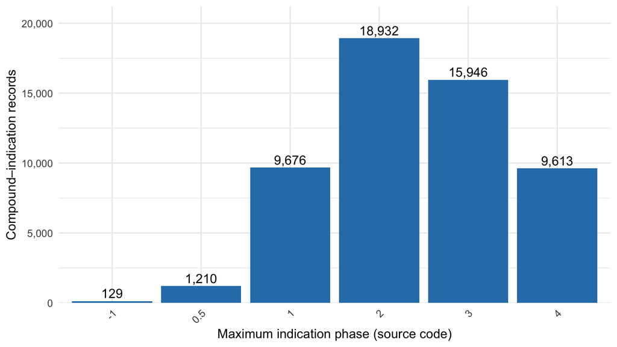

### 4.2.3 Examples of curated indication records

One example per observed phase illustrates the retained disease names, ontology mappings, and compound identifiers. These are deterministic examples from the final object, not a claim of efficacy or current treatment guidance. Parent/child inference flags and supporting reference identifiers remain in the full table for provenance; inferred associations are not discarded here.

| Compound | HDD.Compound.ID | Maximum.Indication.Phase | MeSH.ID | MeSH.Heading | EFO.ID | EFO.Term |
| --- | --- | --- | --- | --- | --- | --- |
| Nicofetamide | HDD_1FaoK1BUx5F2 | -1.0 | D004066 | Digestive System Diseases | EFO:0010282 | gastrointestinal disease |
| Cefixime | HDD_11CAbAxvILTY | 0.5 | D010019 | Osteomyelitis | EFO:0003102 | osteomyelitis |
| Cefixime | HDD_11CAbAxvILTY | 1.0 | D009369 | Neoplasms | EFO:0000616 | neoplasm |
| Cetrorelix Acetate | HDD_11KYre0hi1nf | 2.0 | D007246 | Infertility | EFO:0000545 | infertility |
| Cefixime | HDD_11CAbAxvILTY | 3.0 | D013587 | Syphilis | EFO:0007504 | syphilis |
| Cefixime | HDD_11CAbAxvILTY | 4.0 | D010033 | Otitis Media | EFO:0004992 | Otitis media |

| Inferred.From.Parent | Inferred.From.Child | Records |
| --- | --- | --- |
| FALSE | FALSE | 38801 |
| FALSE | TRUE | 6285 |
| TRUE | FALSE | 10420 |

# 5 Experiment walkthroughs

Below, each experiment in the HDD MAE is reviewed.

## 5.1 Bioassays

A compound-by-assay matrix of PubChem bioassay outcomes. Rows are AIDs (assay identifiers) and columns are `HDD.Compound.ID` values. Entries are categorical outcomes, with missing values representing assay–compound pairs with no outcome in the exported matrix. Missing does not mean inactive.

```
##   rows   cols
##     33 438498
```

|  | HDD_100Qq7ZWzc84 | HDD_100qxkzFVw1Y | HDD_101xneHl8ces | HDD_102MEPXgQBRc | HDD_105EXyYgqwjS | HDD_105YnfuNS7oD |
| --- | --- | --- | --- | --- | --- | --- |
| AID_902 | NA | NA | NA | NA | NA | NA |
| AID_903 | NA | NA | NA | NA | NA | NA |
| AID_904 | NA | NA | NA | NA | NA | NA |
| AID_914 | NA | NA | NA | NA | NA | NA |
| AID_915 | NA | NA | NA | NA | NA | NA |

```
## assay_values
## Missing outcome          Active
##        13892790          577644
```

```
## Inactive values in current Bioassays matrix: 0
```

```
##    Min. 1st Qu.  Median    Mean 3rd Qu.    Max.
##   0.872   0.948   0.988   0.960   0.989   1.000
```

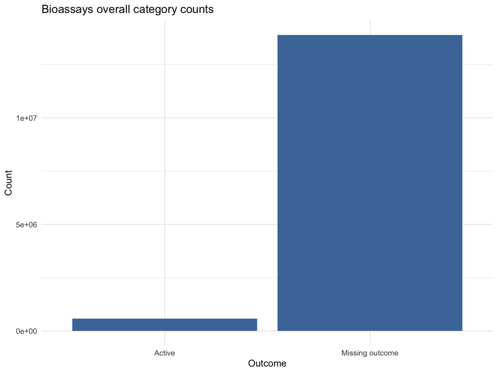

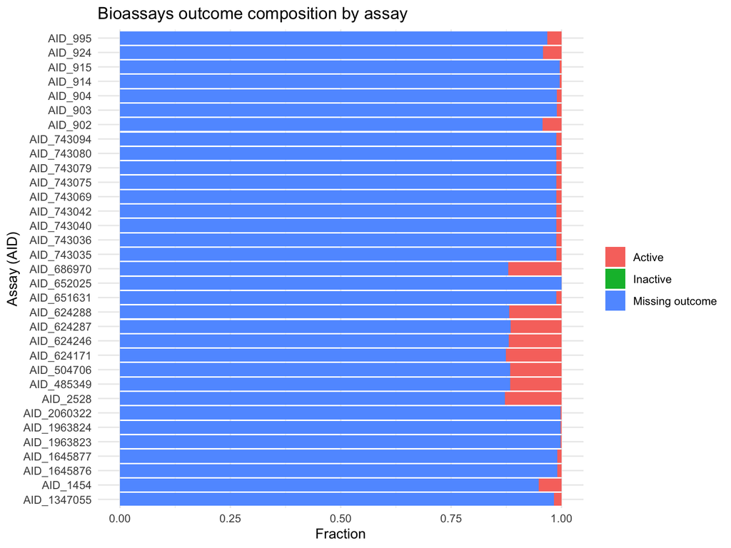

## 5.2 Tox21

Rows are Tox21 assays and columns are `HDD.Compound.ID` values. The NCATS training data supply active (1) and inactive (0) calls. A compound with no call or conflicting calls in an assay has an `NA` for that cell; its other labels stay.

```
## rows cols
##   12 6134
```

|  | HDD_10OljUbbqjzM | HDD_11BV4iHE6N8k | HDD_11EYa1tYTOyP | HDD_11T787bbL3ns | HDD_121lXAdujLmE | HDD_127IkCzLXInA |
| --- | --- | --- | --- | --- | --- | --- |
| NR-AR | 0 | 0 | 0 | NA | 0 | 0 |
| NR-AR-LBD | NA | 0 | 0 | NA | 0 | 0 |
| NR-AhR | 0 | 0 | 0 | NA | 0 | 0 |
| NR-Aromatase | NA | 0 | 0 | NA | 0 | 0 |
| NR-ER | NA | 0 | 0 | NA | NA | 0 |

| Assay | Active | Inactive | Missing |
| --- | --- | --- | --- |
| NR-AR | 227 | 5432 | 475 |
| NR-AR-LBD | 193 | 5062 | 879 |
| NR-AhR | 595 | 4499 | 1040 |
| NR-Aromatase | 217 | 4256 | 1661 |
| NR-ER | 522 | 4181 | 1431 |
| NR-ER-LBD | 244 | 5153 | 737 |
| NR-PPAR-gamma | 139 | 4879 | 1116 |
| SR-ARE | 699 | 3815 | 1620 |
| SR-ATAD5 | 192 | 5317 | 625 |
| SR-HSE | 267 | 4749 | 1118 |
| SR-MMP | 710 | 3809 | 1615 |
| SR-p53 | 333 | 4920 | 881 |

The heatmap shows examples of compounds with the most active calls, not a representative sample. In the rate plot, the denominator is compounds with an observed call for that assay.

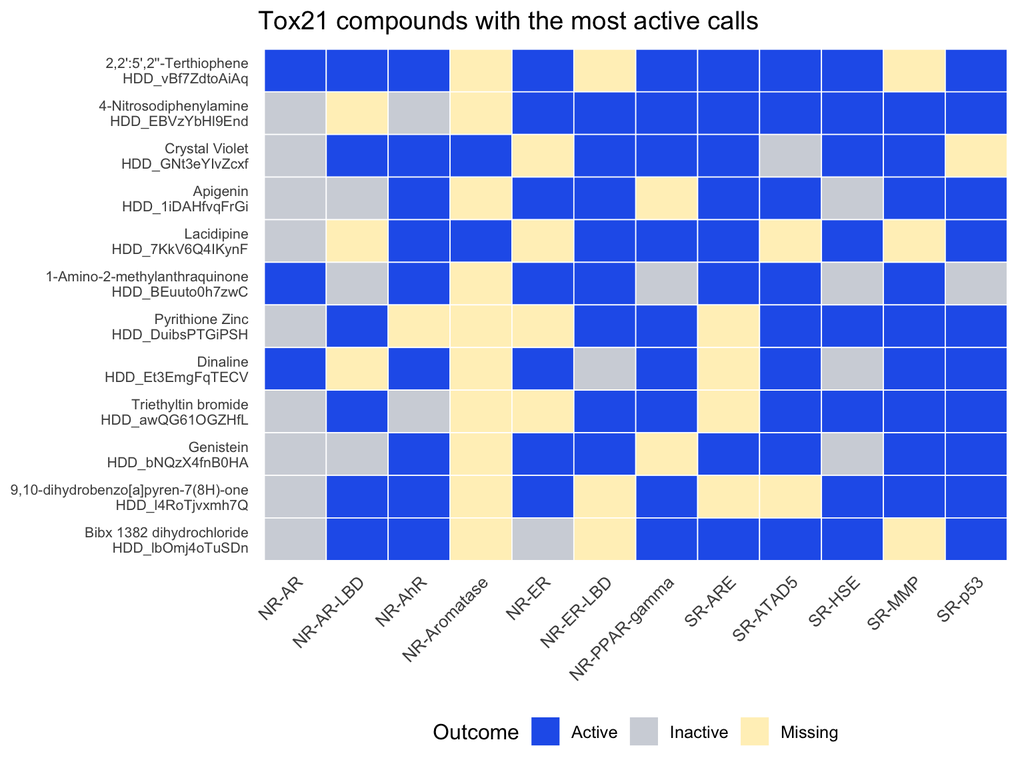

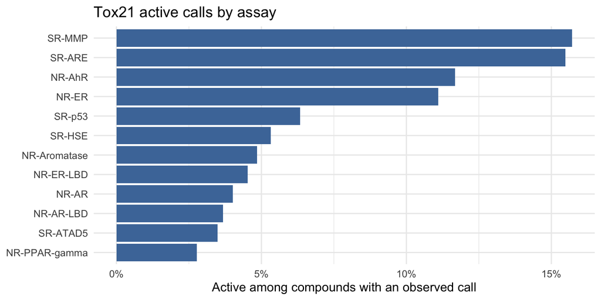

## 5.3 Fingerprints (Morgan count fingerprints)

Count-based Morgan fingerprints generated from parseable SMILES using RDKit. Each fingerprint experiment is stored as a sparse matrix of feature counts with rows as fingerprint bins and columns as the `HDD.Compound.ID` values that produced a fingerprint. Compounds with missing or invalid SMILES remain in `colData` but are not columns in the fingerprint experiments.

```
## [1] "fingerprint.Morgan.2.1024" "fingerprint.Morgan.2.2048"
## [3] "fingerprint.Morgan.3.1024" "fingerprint.Morgan.3.2048"
```

```
## [1] "fingerprint.Morgan.3.1024"
```

| total_compounds | compounds_with_smiles | selected_fingerprint_columns | not_fingerprinted |
| --- | --- | --- | --- |
| 648122 | 647143 | 646039 | 2083 |

```
##
## Fingerprint: fingerprint.Morgan.2.1024
## Dimensions: 1024 x 646039
## Sparsity: 0.956
## 5 x 6 sparse Matrix of class "dgCMatrix"
##    HDD_100Qq7ZWzc84 HDD_100VcBf7xNmF HDD_100qxkzFVw1Y HDD_101gEGLkpWU6
## V1                .                .                .                .
## V2                1                .                .                .
## V3                .                .                .                .
## V4                .                .                .                .
## V5                .                .                .                .
##    HDD_101w9WD4OfLl HDD_101xneHl8ces
## V1                .                .
## V2                .                .
## V3                .                .
## V4                .                .
## V5                .                .
##
## Fingerprint: fingerprint.Morgan.2.2048
## Dimensions: 2048 x 646039
## Sparsity: 0.978
## 5 x 6 sparse Matrix of class "dgCMatrix"
##    HDD_100Qq7ZWzc84 HDD_100VcBf7xNmF HDD_100qxkzFVw1Y HDD_101gEGLkpWU6
## V1                .                .                .                .
## V2                1                .                .                .
## V3                .                .                .                .
## V4                .                .                .                .
## V5                .                .                .                .
##    HDD_101w9WD4OfLl HDD_101xneHl8ces
## V1                .                .
## V2                .                .
## V3                .                .
## V4                .                .
## V5                .                .
##
## Fingerprint: fingerprint.Morgan.3.1024
## Dimensions: 1024 x 646039
## Sparsity: 0.941
## 5 x 6 sparse Matrix of class "dgCMatrix"
##    HDD_100Qq7ZWzc84 HDD_100VcBf7xNmF HDD_100qxkzFVw1Y HDD_101gEGLkpWU6
```

[output cut: 13 more lines]

```
## Dimensions: 2048 x 646039
## Sparsity: 0.97
## 5 x 6 sparse Matrix of class "dgCMatrix"
##    HDD_100Qq7ZWzc84 HDD_100VcBf7xNmF HDD_100qxkzFVw1Y HDD_101gEGLkpWU6
## V1                .                .                .                .
## V2                1                .                .                .
## V3                .                .                .                .
## V4                .                .                .                .
## V5                .                .                .                .
##    HDD_101w9WD4OfLl HDD_101xneHl8ces
## V1                .                .
## V2                .                .
## V3                .                .
## V4                .                .
## V5                .                .
```

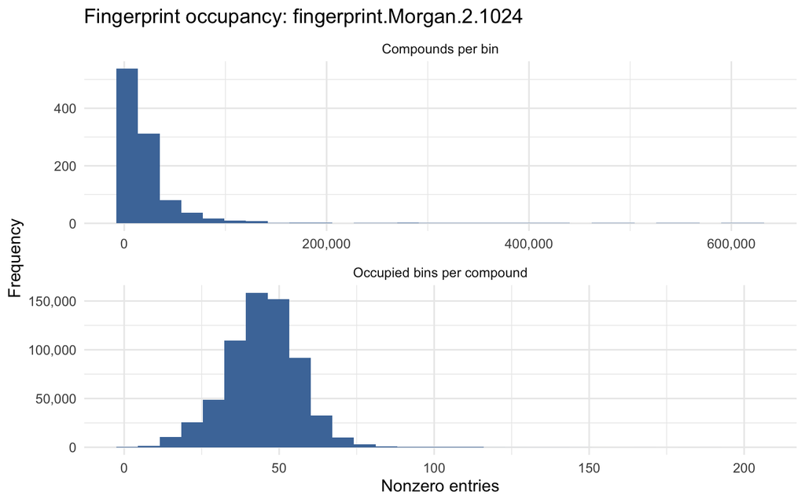

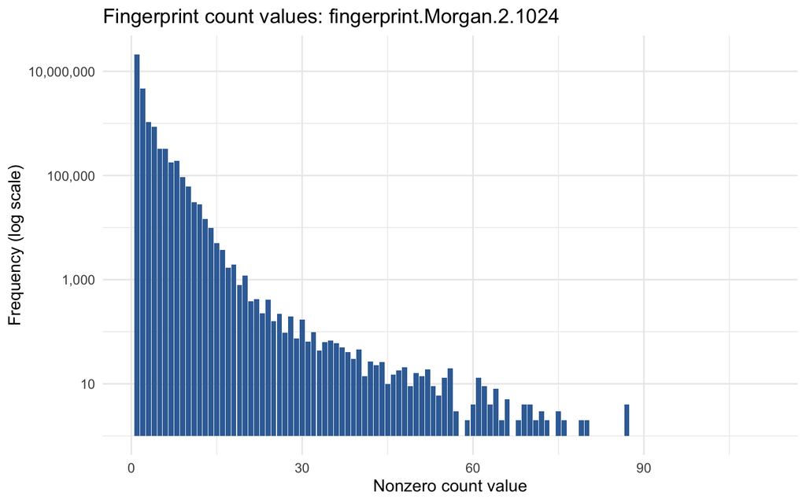

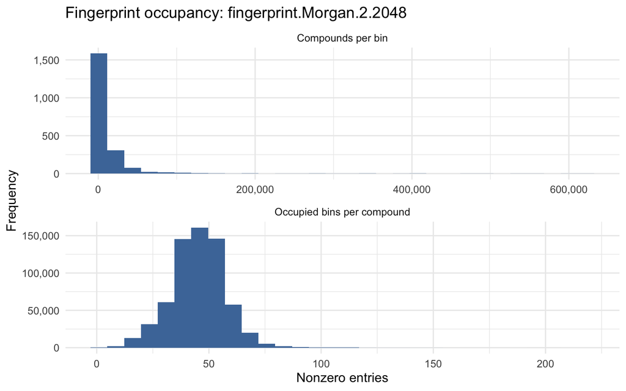

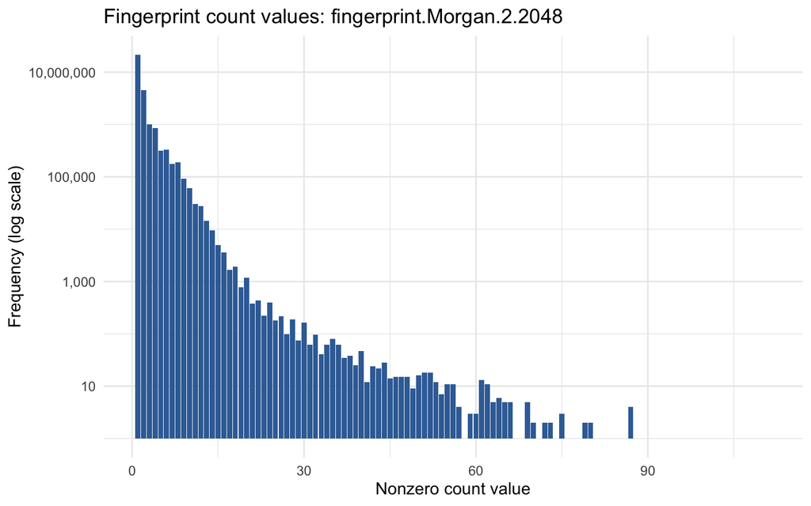

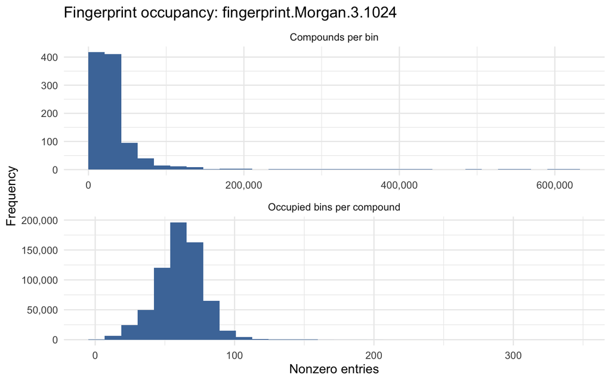

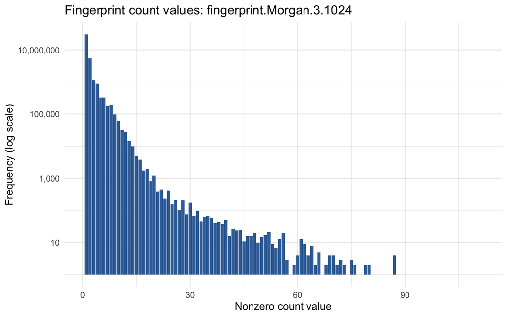

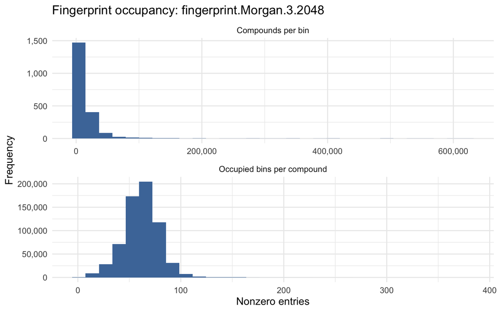

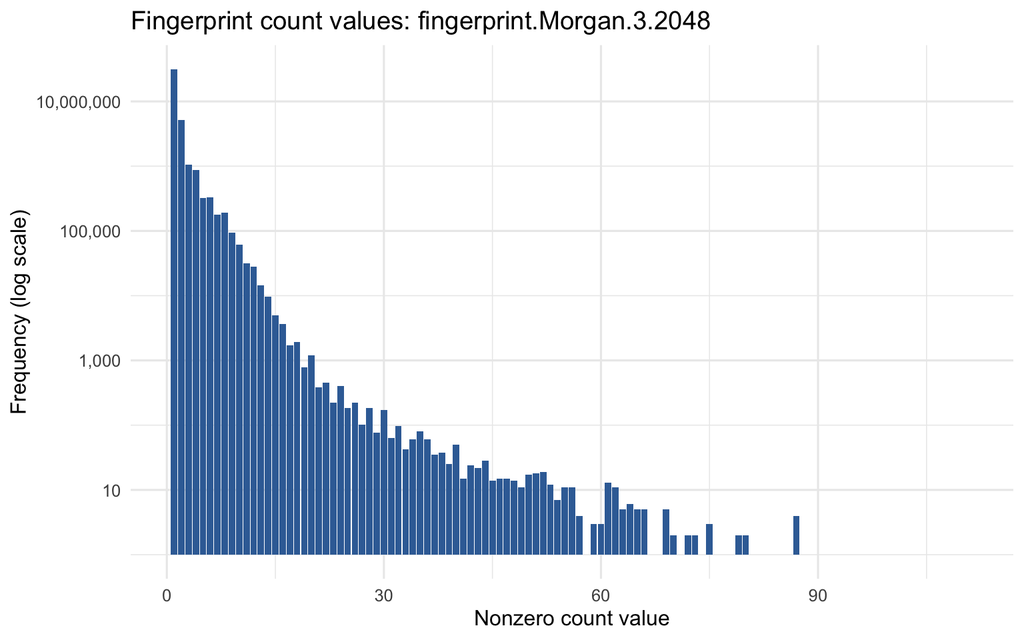

## 5.4 ATC code coverage

`ATC.Code` records Anatomical Therapeutic Chemical classifications where available in the compound metadata.

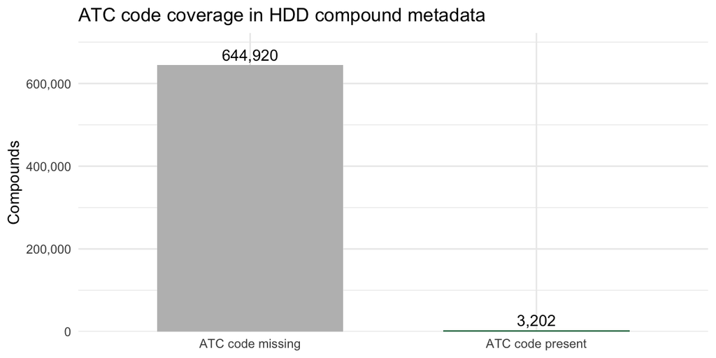

## 5.5 DILI, DIRIL, and DICT coverage

This section summarizes the toxicity metadata currently available in `colData` for liver, renal, and cardiac toxicity labels.

| source | label_set | field | non_missing | unique_non_missing |
| --- | --- | --- | --- | --- |
| LTKB | LTKB Benchmark Dataset | DILI severity grade | 152 | 7 |
| LTKB | LTKB Benchmark Dataset | DILI annotation | 292 | 3 |
| LTKB | DILIrank | DILI severity grade | 1213 | 9 |
| LTKB | DILIrank | DILI annotation | 1213 | 6 |
| LTKB | DILIst | DILI annotation | 1177 | 2 |
| LiverTox | LiverTox | hepatotoxicity likelihood score | 803 | 42 |
| LiverTox | LiverTox | hepatotoxicity likelihood reason | 719 | 183 |

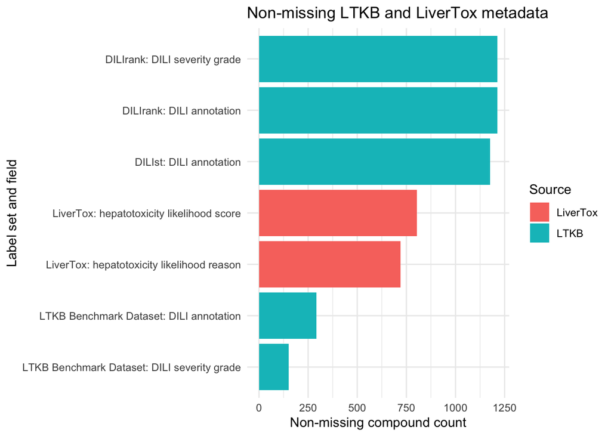

| source | label_set | field | label | n |
| --- | --- | --- | --- | --- |
| LTKB | LTKB Benchmark Dataset | DILI severity grade | 3 | 50 |
| LTKB | LTKB Benchmark Dataset | DILI severity grade | 8 | 48 |
| LTKB | LTKB Benchmark Dataset | DILI severity grade | 5 | 20 |
| LTKB | LTKB Benchmark Dataset | DILI severity grade | 2 | 13 |
| LTKB | LTKB Benchmark Dataset | DILI severity grade | 7 | 12 |
| LTKB | LTKB Benchmark Dataset | DILI severity grade | 4 | 5 |
| LTKB | LTKB Benchmark Dataset | DILI severity grade | 6 | 4 |
| LTKB | LTKB Benchmark Dataset | DILI annotation | most-DILI-concern | 131 |
| LTKB | LTKB Benchmark Dataset | DILI annotation | no-DILI-concern | 82 |
| LTKB | LTKB Benchmark Dataset | DILI annotation | less-DILI-concern drugs | 79 |

[output cut: 81 more lines]

| label_set | column | severity_grade | n |
| --- | --- | --- | --- |
| LTKB Benchmark Dataset | LTKB.DILI.Severity.Grade | 3 | 50 |
| LTKB Benchmark Dataset | LTKB.DILI.Severity.Grade | 8 | 48 |
| LTKB Benchmark Dataset | LTKB.DILI.Severity.Grade | 5 | 20 |
| LTKB Benchmark Dataset | LTKB.DILI.Severity.Grade | 2 | 13 |
| LTKB Benchmark Dataset | LTKB.DILI.Severity.Grade | 7 | 12 |
| LTKB Benchmark Dataset | LTKB.DILI.Severity.Grade | 4 | 5 |
| LTKB Benchmark Dataset | LTKB.DILI.Severity.Grade | 6 | 4 |
| DILIrank | DILIrank.DILI.Severity.Grade | 0 | 415 |
| DILIrank | DILIrank.DILI.Severity.Grade | 3 | 366 |
| DILIrank | DILIrank.DILI.Severity.Grade | 8 | 164 |

[output cut: 6 more lines]

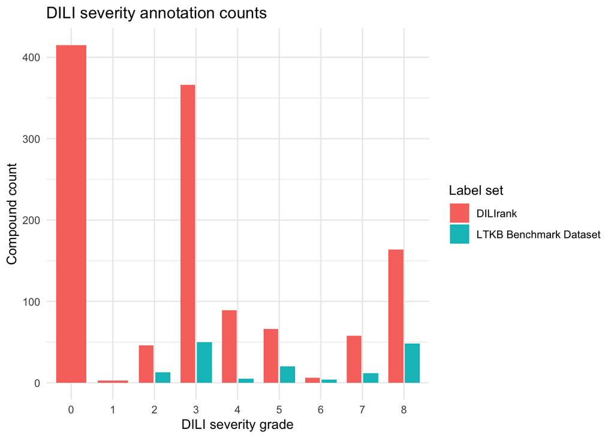

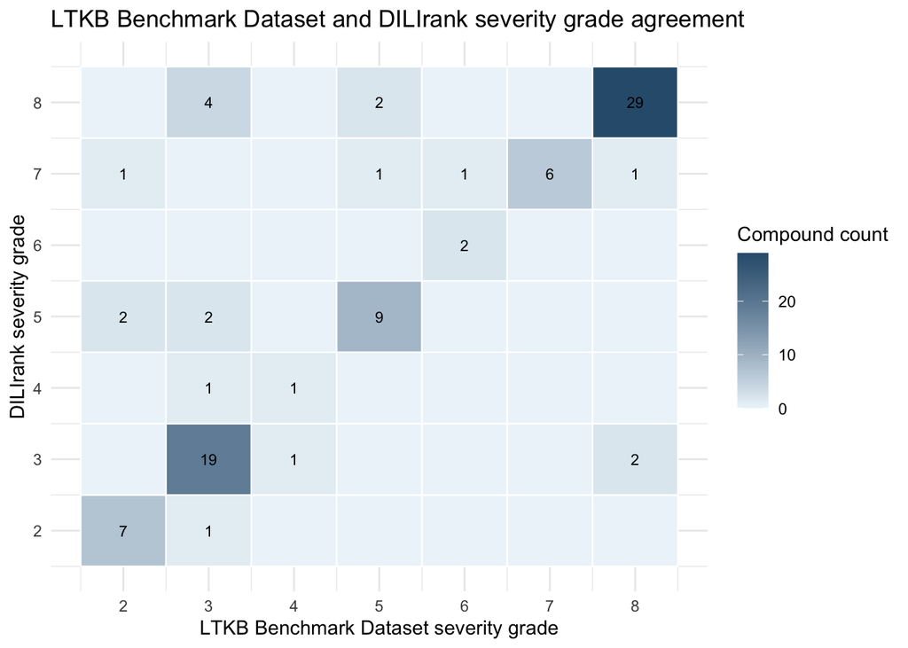

| source | field | column | non_missing | unique_non_missing |
| --- | --- | --- | --- | --- |
| DIRIL | Gong label | DIRIL.Label.Gong | 176 | 2 |
| DIRIL | Shi label | DIRIL.Label.Shi | 255 | 2 |
| DIRIL | final toxicity label | DIRIL.Toxicity | 317 | 2 |
| DICT | cardiotoxicity class | DICT.Cardiotoxicity | 793 | 3 |
| DICT | label section | DICT.Label.Section | 1198 | 8 |
| DICT | concern | DICT.Concern | 1198 | 5 |
| DICT | keywords | DICT.Keywords | 974 | 552 |

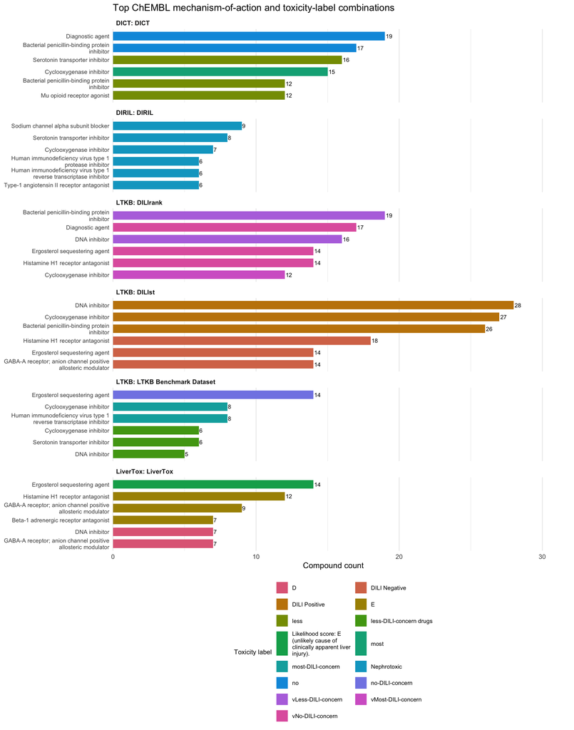

| Gong | Shi | Final | n |
| --- | --- | --- | --- |
| Non-Nephrotoxic | Non-Nephrotoxic | Non-Nephrotoxic | 71 |
| Nephrotoxic | Nephrotoxic | Nephrotoxic | 22 |
| Non-Nephrotoxic | Nephrotoxic | Nephrotoxic | 14 |
| Nephrotoxic | Non-Nephrotoxic | Nephrotoxic | 3 |
| Non-Nephrotoxic | Nephrotoxic | Non-Nephrotoxic | 3 |
| Non-Nephrotoxic | Non-Nephrotoxic | Nephrotoxic | 1 |

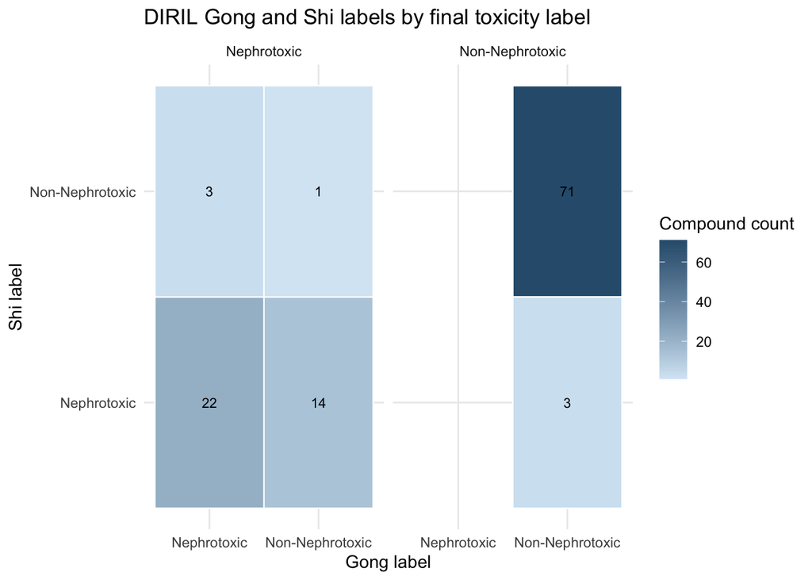